# Vertical movement analysis

### Add daily bathymetry based on the trajectory files obtained from the geolocation models

Note that I will not use this, but leave the code as is just in case.

```r
# Link trajectory data (source trajectory data script)
tr_data <- read_csv("./data/external/trajectory_data/eel_trajectories.csv")
# Select columns
tr_data <- dplyr::select(tr_data, ID, Date, Max_Depth)
tr_data <- rename(tr_data,
                  max_depth_bathymetry = Max_Depth)

# Process columns
tr_data$Date <- dmy(tr_data$Date)
tr_data$ID <- factor(tr_data$ID)

# Remove double dates per eel (ID)
#tr_data <- tr_data[!duplicated(tr_data[c('ID','Date')]),]
tr_data <- tr_data %>%     # Add ID number to duplicate dates
  group_by(ID, Date) %>%
  add_tally()

duplicates <- filter(tr_data, n == 2)   # Filter duplicate dates
duplicates <- duplicates %>%             # Add ID number to distinguish between first and second duplicate
  mutate(number_id = row_number())
duplicates <- filter(duplicates, number_id == 2)  # Filter second duplicates

tr_data <- filter(tr_data, n != 2)   # Remove duplicate dates from tracking dataset

# Bind 'duplicates' dataset with second duplicates to tracking dataset
tr_data <- ungroup(tr_data)
tr_data$n <- NULL
duplicates <- ungroup(duplicates)
duplicates$n <- NULL
duplicates$number_id <- NULL

tr_data <- rbind(tr_data, duplicates)

# Select relevant eels
tr_data <- filter(tr_data, ID == "16031" |
                   ID == "17535" |
                   ID == "17536" |
                   ID == "15777" |
                   ID == "17510")

tr_data$ID <- factor(tr_data$ID) # rerun 'factor()' so the number of levels is set accurately

data_5eels$Date <- as.Date(data_5eels$Date)
data_5eels <- left_join(data_5eels, tr_data, by = c('ID', 'Date'))

# Remove line with max depth bathymetry > 300 m --> remove location in deep sea
#data_5eels$max_depth_bathymetry <- as.numeric(data_5eels$max_depth_bathymetry)
#data_5eels <- filter(data_5eels, max_depth_bathymetry >= -300)
```

Plot the daily depth range, the max depth and the max depth bathymetry. The latter 2 do not differ a lot because one of the assumptions in the geolocation model is that the eel’s daily depth is the daily max bathymetry.

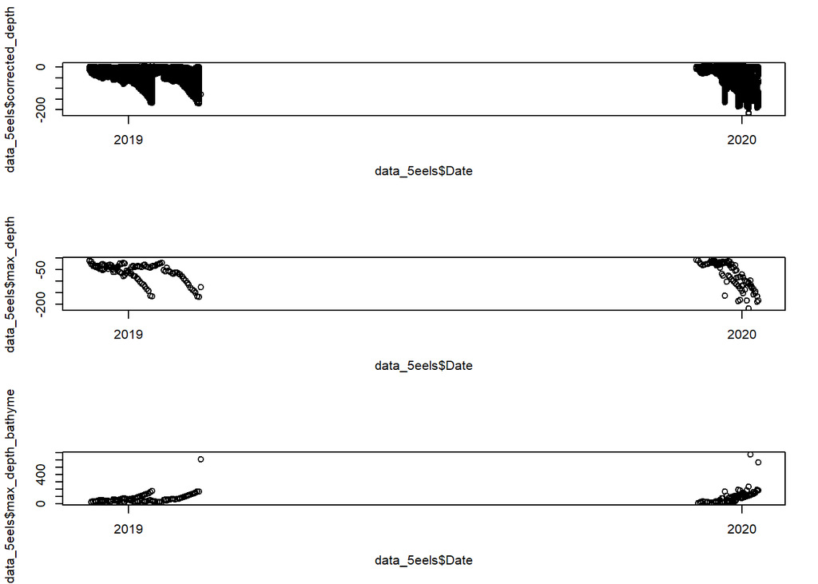

```r
par(mfrow=c(3,1))
plot(data_5eels$Date, data_5eels$corrected_depth)
plot(data_5eels$Date, data_5eels$max_depth)
plot(data_5eels$Date, data_5eels$max_depth_bathymetry)
```

### Calculate the relative depth

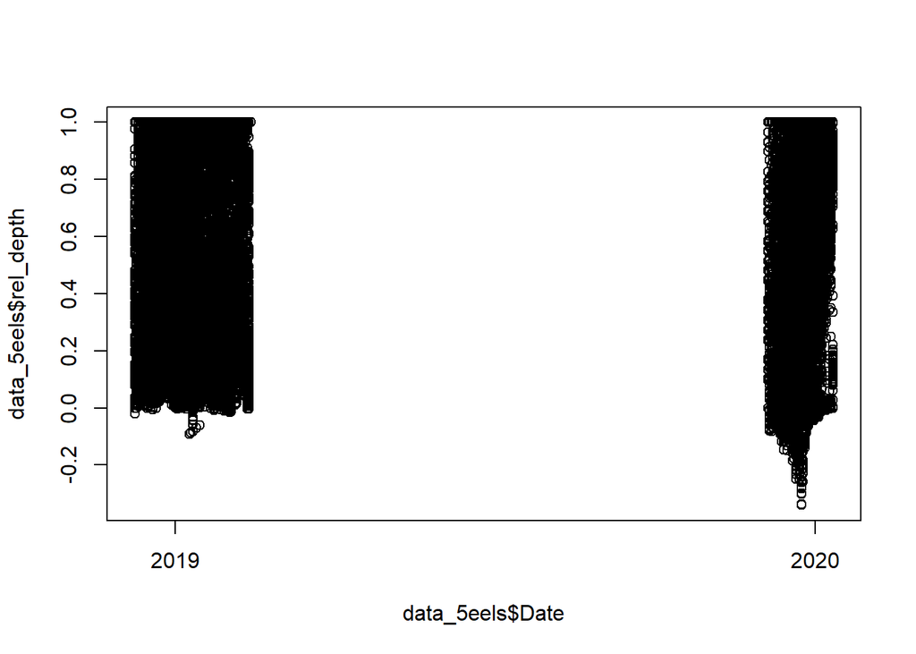

```r
data_5eels$rel_depth <- data_5eels$corrected_depth / data_5eels$max_depth
plot(data_5eels$Date, data_5eels$rel_depth)
```

### Create factor indicating if the sun is rising or setting

```r
# Remove rows with NA values
data_5eels <- na.omit(data_5eels)

# Classify sun_altitude as rising or setting sun
data_5eels$sun_class <- NA
  for (i in 2:dim(data_5eels)[1]){
    if (data_5eels$sun_altitude[i] > data_5eels$sun_altitude[i-1]){
      data_5eels$sun_class[i] = "rising"
    } else{
      data_5eels$sun_class[i] = "setting"
    }}

# Set as factor
data_5eels$sun_class <- factor(data_5eels$sun_class)

# Remove first line of each eel, since that "sun_class" value is incorrect. The for-loop does not take into account different eels, but runs over the complete dataset.
data_5eels <- data_5eels %>%
  group_by(ID) %>%
  slice(-1)
```

## Scale variables

For model construction, the exploratory variables need to be scaled. Max value should be between 0.5 - 5.

```r
# direction_x
summary(data_5eels$direction_x)
```

```
##      Min.   1st Qu.    Median      Mean   3rd Qu.      Max.
## -1.755500 -0.264700 -0.003000  0.007684  0.280800  1.614200
```

```r
# direction_y
summary(data_5eels$direction_y)
```

```
##      Min.   1st Qu.    Median      Mean   3rd Qu.      Max.
## -1.349200 -0.183000 -0.001000  0.009851  0.203600  1.720400
```

```r
# Temperature
summary(data_5eels$temperature)
```

```
##    Min. 1st Qu.  Median    Mean 3rd Qu.    Max.
##   6.391   9.547  10.703  10.548  11.688  13.203
```

```r
data_5eels$temperature_scaled <- data_5eels$temperature / 10

# Moon illumination
summary(data_5eels$moon_fraction)
```

```
##      Min.   1st Qu.    Median      Mean   3rd Qu.      Max.
## 0.0000752 0.1598697 0.4552128 0.4806714 0.8092580 0.9999797
```

```r
# Sun altitude
summary(data_5eels$sun_altitude)
```

```
##    Min. 1st Qu.  Median    Mean 3rd Qu.    Max.
## -1.1415 -0.7938 -0.2910 -0.3353  0.1378  0.5006
```

```r
# Sun azimuth
summary(data_5eels$sun_azimuth)
```

```
##       Min.    1st Qu.     Median       Mean    3rd Qu.       Max.
## -3.1415520 -1.3090434  0.0000505  0.0138621  1.3106045  3.1411577
```

### Construct model with AR1 covariance structure

```r
data_5eels <- data_5eels %>%
  arrange(ID, datetime) %>%
  group_by(ID) %>%
  mutate(times = factor(row_number()))
```

#### glmer from lme4 package

When running the glmer() function, it gives an error. Not sure why, but based on fora searches it might have to do with the data complexity and/or size.

```r
#model_glmer <- glmer(rel_depth ~ direction_x_centre +
#                   direction_y_centre +
#                   moon_fraction_centre +
#                   sun_altitude_centre +
#                   sun_azimuth_centre +
#                 (1|ID),
#                 data = data_5eels,
#                 family = beta_family(),
#                 na.action = na.omit)
#summary(model_glmer)
```

Returns the following error:

```r
#  Error in (function (fr, X, reTrms, family, nAGQ = 1L, verbose = 0L, maxit = 100L, :
#(maxstephalfit) PIRLS step-halvings failed to reduce deviance in pwrssUpdate
```

#### glmmTMB from the glmmTMB package

The function glmmTMB() runs when no AR1 construct is implemented. For more info on the method implementation, see [this website](https://cran.r-project.org/web/packages/glmmTMB/vignettes/covstruct.html). The [glmmTMB](https://cran.r-project.org/web/packages/glmmTMB/vignettes/glmmTMB.pdf) R-package was used.

Update: I included the positive corrected_depth values, hence, the rel_depth now contains negative values so a model with beta-distribution is unable to run.

```r
summary(data_5eels$rel_depth)
```

```
##     Min.  1st Qu.   Median     Mean  3rd Qu.     Max.
## -0.34012  0.09211  0.52734  0.48313  0.83675  1.00000
```

```r
#model_tmb <- glmmTMB(rel_depth ~ direction_x +
#                   direction_y +
#                   moon_fraction +
#                   sun_altitude +
#                   sun_azimuth,
#                 data = data_5eels,
#                 family = beta_family(),
#                 na.action = na.omit)
#summary(model_tmb)
```

When the AR1 term is added, a memory error occurs. This is probably due to the fact that this function is rather viable for datasets up to 100k (see [documentation](https://m-clark.github.io/posts/2019-10-20-big-mixed-models/))

```r
#model_tmb_ar1 <- glmmTMB(rel_depth ~ direction_x_centre +
#                   direction_y_centre +
#                   moon_fraction_centre +
#                   sun_altitude_centre +
#                   sun_azimuth_centre +
#                 ar1(times + 0 | ID),
#                 family = beta_family(),
#                 data = subset)
```

Returns the following error:

```r
#Error: cannot allocate vector of size 4.8 Gb
```

#### bam from the mgcv package

The function bam from the mgcv package is designed for large datasets (see [documentation](https://m-clark.github.io/posts/2019-10-20-big-mixed-models/)).

To implement the AR1 strucgture in the model, select the first record per eel and flag as true.

```r
# Select first record per eel and flag as 'TRUE'
t.first <- data_5eels[match(unique(data_5eels$ID), data_5eels$ID),]
t.first <- select(t.first, ID, datetime)
t.first$start.event <- TRUE

# Merge with dataset
data_5eels <- left_join(data_5eels, t.first, by = c("ID", "datetime"))

# Set NA as FALSE
data_5eels[c("start.event")][is.na(data_5eels[c("start.event")])] <- FALSE
```

```r
# Run gamm model with autocorrelation argument

# Full model
bam_model <- bam(rel_depth ~ s(direction_x) +
                   s(direction_y) +
                   s(moon_fraction) +
                   s(sun_altitude) +
                   s(sun_azimuth) +
                   sun_class +
                   s(ID, bs="re"),
                 family = gaussian(), data = data_5eels, discrete = TRUE,
                 #AR.start=subset$start.event,
                 rho=0.90,
                 na.action = na.omit)
```

Calculate rho (= acf value) which can be fed into the bam_model for model optimisation. However, this results in an error for a model of the beta family.

```r
# Calculate Rho, the autocorrelation value of a specific lag
#valRho <- acf(resid(bam_model), plot=TRUE)$acf[2]
```

```r
#Error in plot.window(...) : need finite 'ylim' values
```

Show summary of the model

```r
summary(bam_model)
```

```
##
## Family: gaussian
## Link function: identity
##
## Formula:
## rel_depth ~ s(direction_x) + s(direction_y) + s(moon_fraction) +
##     s(sun_altitude) + s(sun_azimuth) + sun_class + s(ID, bs = "re")
##
## Parametric coefficients:
##                  Estimate Std. Error t value Pr(>|t|)
## (Intercept)      0.477439   0.037303   12.80   <2e-16 ***
## sun_classsetting 0.002718   0.007542    0.36    0.719
## ---
## Signif. codes:  0 '***' 0.001 '**' 0.01 '*' 0.05 '.' 0.1 ' ' 1
##
## Approximate significance of smooth terms:
##                    edf Ref.df      F  p-value
## s(direction_x)   4.361  5.591  1.809    0.098 .
## s(direction_y)   1.001  1.001  0.651    0.420
## s(moon_fraction) 4.236  5.194  1.659    0.137
## s(sun_altitude)  1.001  1.001  0.325    0.569
## s(sun_azimuth)   4.670  5.855  5.226 3.15e-05 ***
## s(ID)            3.814  5.000 16.758  < 2e-16 ***
## ---
## Signif. codes:  0 '***' 0.001 '**' 0.01 '*' 0.05 '.' 0.1 ' ' 1
##
## R-sq.(adj) =  0.0499   Deviance explained = 5.04%
## fREML = -18593  Scale est. = 0.13465   n = 45020
```

Check the model

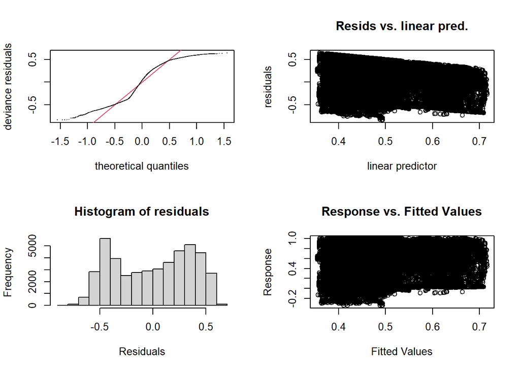

```
##
## Method: fREML   Optimizer: perf chol
## $grad
## [1]  1.562343e-06 -3.118314e-04  1.348723e-06 -2.585771e-04  5.227809e-05
## [6]  3.020207e-07  1.004495e-04
##
## $hess
##            [,1]          [,2]          [,3]          [,4]          [,5]
##    8.215911e-01 -9.877175e-06  1.445064e-02 -1.563327e-06  4.341655e-03
##   -9.877175e-06  3.117270e-04  5.399458e-06 -2.759905e-10  2.845264e-06
##    1.445064e-02  5.399458e-06  5.593165e-01 -1.391139e-06  6.930835e-03
##   -1.563327e-06 -2.759905e-10 -1.391139e-06  2.584836e-04 -5.221674e-05
##    4.341655e-03  2.845264e-06  6.930835e-03 -5.221674e-05  1.165441e+00
##    7.553825e-03 -2.268884e-07  1.127069e-02 -3.021913e-07 -5.409676e-03
## d -1.680286e+00 -6.103953e-05 -1.618025e+00 -1.002699e-04 -1.834949e+00
##            [,6]          [,7]
##    7.553825e-03 -1.680286e+00
##   -2.268884e-07 -6.103953e-05
##    1.127069e-02 -1.618025e+00
##   -3.021913e-07 -1.002699e-04
##   -5.409676e-03 -1.834949e+00
##    1.818722e+00 -1.906891e+00
## d -1.906891e+00  2.250650e+04
##
## Model rank =  52 / 52
##
## Basis dimension (k) checking results. Low p-value (k-index<1) may
## indicate that k is too low, especially if edf is close to k'.
##
##                    k'  edf k-index p-value
## s(direction_x)   9.00 4.36    0.67  <2e-16 ***
## s(direction_y)   9.00 1.00    0.68  <2e-16 ***
## s(moon_fraction) 9.00 4.24    0.94  <2e-16 ***
## s(sun_altitude)  9.00 1.00    1.00    0.35
## s(sun_azimuth)   9.00 4.67    0.98    0.10
## s(ID)            5.00 3.81      NA      NA
## ---
## Signif. codes:  0 '***' 0.001 '**' 0.01 '*' 0.05 '.' 0.1 ' ' 1
```

```r
par(mfrow = c(2, 2))
gam.check(bam_model)
```